# Assignment 5

Sean Wells

#### Due Friday, October 15, 11:59 PM

### Baseball Preface

- The following code chunk will read in each of the data files from the 2021 major league baseball season and do some slight transformations.
- The code chunk has the argument `include = FALSE` set, so it will not appear in the knitted document.
- The first several problems use this data and ask you to use various `*_join()` functions to combine data from different files together.
- There are many columns with statistics that we will not use.
- Those needed for a particular problem will be described as needed.
- You do not need to be familiar with the rules of baseball or knowledgeable about the teams to solve the problems

#### File Descriptions

- The basic *player* data sets have one row for each player if the player played for a single team the entire season.
- If the player played for multiple teams, then there is one row for that player for each team that the player played for and an additional row with the combined statistics over the year.
  - The combined row has the variable `Tm` for team set to `TOT` for total
- The value *player* data sets have one row for each player
- Files with the word *pitching* contain statistics about the part of the game where a player in the role of a pitcher throws the ball toward the plate
- Files with the word *batting* contain statistics about the part of the game where a player in the role of a batter stands with a bat at the plate and reacts to the pitched ball.
- Most players in major league baseball are primarily either pitchers or position players, but some players will do both
  - In the National League, pitchers are in the lineup and so tend to bat much more often than in the American League where the pitcher is replaced by a *designated hitter* in the lineup.
  - Occasionally, a player who is primarily a position player will pitch
- The *team* and *standings* data files contain statistics aggregated over all players who played for that team.
- There are 30 major league baseball teams
  - There are 15 teams each in the American and National Leagues
  - Each League is divided into three divisions of five teams each with the names East, Central, and West
- The variable `Tm` for team is recorded differently in different files
  - The *player* data files variable `Tm` is a three-letter abbreviation for the team (or `TOT` for total).
  - The *team* and *standings* data files variable `Tm` is the full team name
  - Each full team name begins with a location (most often a city, but occasionally a state)
- The 2021 regular season ended on Sunday, October 3. Playoffs are currently under way.
- The only team from Wisconsin, the Milwaukee Brewers, are in the playoffs and begin a best-of-five series versus the Atlanta Braves on Friday, October 8.

### 1

The data sets `player_bat_basic` and `player_bat_value` contain summary statistics from every player that appeared as a batter in a major league baseball game. The data sets `player_pitch_basic` and `player_pitch_value` contain summary statistics from every player that appeared as a pitcher in a major league baseball game.

- The *value* data sets should have a single row per player.
- The *basic* data sets have a single row for most players, but players that appeared for more than one team have a single row for each team for which they appeared with an additional row for their combined batting or pitching statistics designated by the `Tm` variable having the value `TOT`
- As some players might have the same name, the column `ID` contains a unique identifier for each player

### (a)

Are there any players listed in one of `player_bat_basic` or `player_bat_value` but not the other? Describe any discrepancies you discover.

There is one player listed in ‘player_bat_value’ but not ‘player_bat_basic’ and both pitching data sets include the same players. The statistics measured in both the value and basic data sets also seem to be mostly different.

Write code using the function `anti_join()` to answer the question.

### (b)

Repeat for the files `player_pitch_basic` and `player_pitch_value`

```r
anti_join(player_bat_value, player_bat_basic, by="ID")
```

```
## # A tibble: 1 × 24
##   Name      ID       Age Tm        G    PA  Rbat Rbaser   Rdp Rfield  Rpos   RAA
##   <chr>     <chr>  <dbl> <chr> <dbl> <dbl> <dbl>  <dbl> <dbl>  <dbl> <dbl> <dbl>
## 1 David Ph… phelp…    34 TOR       0     0     0      0     0      0     0     0
## # … with 12 more variables: WAA <dbl>, Rrep <dbl>, RAR <dbl>, WAR <dbl>,
## #   waaWL% <dbl>, 162WL% <dbl>, oWAR <dbl>, dWAR <dbl>, oRAR <dbl>,
## #   Salary <chr>, Acquired <chr>, Pos Summary <chr>
```

```r
anti_join(player_pitch_value, player_pitch_basic, by="ID")
```

```
## # A tibble: 0 × 25
## # … with 25 variables: Name <chr>, ID <chr>, Age <dbl>, Tm <chr>, IP <dbl>,
## #   G <dbl>, GS <dbl>, R <dbl>, RA9 <dbl>, RA9opp <dbl>, RA9def <dbl>,
## #   RA9role <dbl>, RA9extras <dbl>, PPFp <dbl>, RA9avg <dbl>, RAA <dbl>,
## #   WAA <dbl>, gmLI <dbl>, WAAadj <dbl>, WAR <dbl>, RAR <dbl>, waaWL% <dbl>,
## #   162WL% <dbl>, Salary <chr>, Acquired <chr>
```

### 2

Create a data frame with one row for each team with the following variables:

- `Team` and `Abbr` from `abbr`
- `League` from the `Lg` variable of a *player* data set as matches `Abbr` matches `Tm`
- `Division` from the divisions data set
- `W` and `L` from `standings`
- `Pct` equal to `W/(W+L)`

Arrange the rows by division, and then from highest to lowest winning percentage within division. Print the entire table.

```r
league = player_bat_basic %>%
  select(
    Abbr = Tm,
    League = Lg
  ) %>%
  distinct()

complete = divisions %>%
  inner_join(standings, join_by = Tm) %>%
  select(
    Team = Tm,
    Division,
    W,
    L,
    "W-L%"
  ) %>%
  inner_join(abbr, join_by = Team) %>%
  inner_join(league, join_by = Abbr) %>%
  arrange(by_group = Division, desc("W-L%"))
complete
```

```
## # A tibble: 30 × 7
##    Team               Division       W     L `W-L%` Abbr  League
##    <chr>              <chr>      <dbl> <dbl>  <dbl> <chr> <chr>
##  1 Chicago White Sox  AL Central    93    69  0.574 CHW   AL
##  2 Cleveland Indians  AL Central    80    82  0.494 CLE   AL
##  3 Detroit Tigers     AL Central    77    85  0.475 DET   AL
##  4 Kansas City Royals AL Central    74    88  0.457 KCR   AL
##  5 Minnesota Twins    AL Central    73    89  0.451 MIN   AL
##  6 Tampa Bay Rays     AL East      100    62  0.617 TBR   AL
##  7 Boston Red Sox     AL East       92    70  0.568 BOS   AL
##  8 New York Yankees   AL East       92    70  0.568 NYY   AL
##  9 Toronto Blue Jays  AL East       91    71  0.562 TOR   AL
## 10 Baltimore Orioles  AL East       52   110  0.321 BAL   AL
## # … with 20 more rows
```

### 3

Using the table created in the previous problem, select the columns `Abbr`, `Division`, and add a new column named `Place` that takes the values from 1 to 5 from the teams with the highest to lowest winning percentages in each division. (Do not worry about dealing with ties.) Then, reshape this table to a wider format with `Place` as one column and the six division names as other column names with the team abbreviations sorted from first to last place within each division column making up the values of the table interior. Display the entire table.

```r
complete %>%
  group_by(Division) %>%
      mutate(
        Place = row_number()
      ) %>%
  select(Abbr, Division, Place) %>%
  pivot_wider(names_from = Division, values_from = Abbr)
```

```
## # A tibble: 5 × 7
##   Place `AL Central` `AL East` `AL West` `NL Central` `NL East` `NL West`
##   <int> <chr>        <chr>     <chr>     <chr>        <chr>     <chr>
## 1     1 CHW          TBR       HOU       MIL          ATL       SFG
## 2     2 CLE          BOS       SEA       STL          PHI       LAD
## 3     3 DET          NYY       OAK       CIN          NYM       SDP
## 4     4 KCR          TOR       LAA       CHC          MIA       COL
## 5     5 MIN          BAL       TEX       PIT          WSN       ARI
```

### 4

This problem seeks to identify the best batters among players that are primarily pitchers. The variable `OPS` stands for on base percentage plus slugging percentage, an important baseball statistic for offensive production. High values refer to players that get on base often and hit for power.

Create a data frame with all players with at least 50 plate appearances as a batter (`PA >= 50`) and at least 50 innings pitched (`IP >= 50`). Use `ID` to join data from different tables. Retain the variables `Name`, `Tm`, `PA`, `BA`, `HR`, and `OPS` from the basic batting data set and the variables `ERA`, `SO`, and `IP` from the basic pitching data set. Sort the table in descending order of `OPS`. Display the first ten rows of the data set and all columns.

```r
pitch_bat = inner_join(player_pitch_basic, player_bat_basic, by = "ID") %>%
  filter(PA > 50, IP > 50) %>%
  select(
    Name = "Name.x",
    Tm = "Tm.x",
    PA,
    BA,
    HR = "HR.y",
    OPS,
    ERA,
    SO = "SO.x",
    IP
  ) %>%
  arrange(desc(OPS))
head(pitch_bat, 10)
```

```
## # A tibble: 10 × 9
##    Name           Tm       PA    BA    HR   OPS ERA      SO    IP
##    <chr>          <chr> <dbl> <dbl> <dbl> <dbl> <chr> <dbl> <dbl>
##  1 Shohei Ohtani  LAA     639 0.257    46 0.965 3.18    156 130.
##  2 German Marquez COL      60 0.264     1 0.679 4.40    176 180
##  3 Max Fried      ATL      67 0.273     0 0.649 3.04    158 165.
##  4 Jon Lester     TOT      51 0.167     1 0.471 4.71     91 141.
##  5 Jon Lester     WSN      51 0.167     1 0.471 5.02     51  75.1
##  6 Jon Lester     STL      51 0.167     1 0.471 4.36     40  66
##  7 Wade Miley     CIN      59 0.185     0 0.469 3.37    125 163
##  8 Julio Urias    LAD      70 0.203     0 0.454 2.96    195 185.
##  9 Logan Webb     SFG      53 0.13      1 0.449 3.03    158 148.
## 10 Aaron Nola     PHI      63 0.143     0 0.416 4.63    223 180.
```

Make a boxplot of the `OPS` variable. Describe any notable features in this plot.

The distribution of OPS of pitchers with more than 50 innings pitched and 50 plate appearances is roughly symmetric with a median around 0.30. There is one outlier of Shohei Ohtani who had an OPS around 0.30 higher than the next highest pitcher.

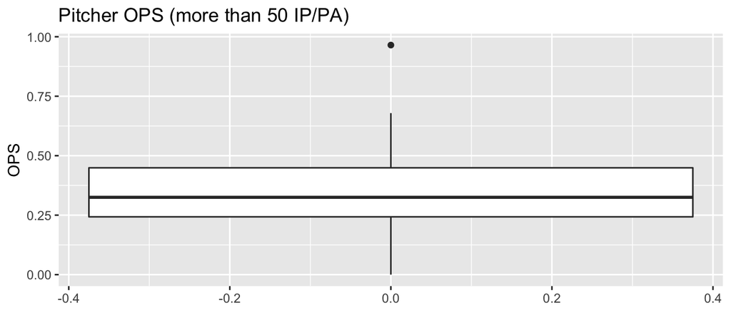

```r
pitch_bat %>%
  ggplot(aes(y=OPS)) +
  geom_boxplot() +
  ggtitle("Pitcher OPS (more than 50 IP/PA)")
```

### 5

Read in the `obesity.csv` file. Create a subset of the obesity data such that:

- there are no rows from children aged 5–17;
- retain a zip code only if there is no missing obesity data for all four age groups for each sex
  - there must be eight non-missing data observations per retained zip code
  - you may find it useful to create a data summary by zip code with the number of adult rows without missing data first to identify the zip codes to keep
- filter out zip/sex/age cohorts with missing obesity data
- calculate the estimated number of adults in the population in each remaining zip code and sex from the age groups where we have obesity data who are obese
- calculate the estimated proportion of adults in each zip code and sex (for age groups with obesity data) who are obese

The resulting data frame should have the following columns of data.

- `zip` = zip code
- `sex` = sex (male or female)
- `adult_n` = estimated # of adults (by zip and sex)
- `obese_n` = estimated # of obese adults (by zip and sex)
- `obese_p` = estimated proportion of obese adults (by zip and sex)

```r
obesity = read_csv("../../data/obesity.csv")
adults = obesity %>%
  filter(age != "05-17")

zips = adults %>%
  filter(complete.cases(obesity%>%filter(age != "05-17"))) %>%
  group_by(zip, sex) %>%
  count() %>%
  filter(n == 4) %>%
  group_by(zip) %>%
  count() %>%
  filter(n == 2)

zip_str = zips$zip %>%
  str_c(collapse="|")

adults_obese = adults %>%
  filter(str_detect(adults$zip, zip_str)) %>%
  group_by(zip, sex) %>%
  summarize(
    sex = str_to_title(sex),
    adult_n = sum(n),
    obese_n = sum(obese),
  ) %>%
  mutate(obese_p = obese_n/adult_n) %>%
  distinct()
adults_obese
```

```
## # A tibble: 612 × 5
## # Groups:   zip, sex [612]
##      zip sex    adult_n obese_n obese_p
##    <dbl> <chr>    <dbl>   <dbl>   <dbl>
##  1 53002 Female     549     211   0.384
##  2 53002 Male       475     201   0.423
##  3 53005 Female    2965     789   0.266
##  4 53005 Male      2211     760   0.344
##  5 53010 Female    1349     550   0.408
##  6 53010 Male      1132     507   0.448
##  7 53012 Female    2695     815   0.302
##  8 53012 Male      2234     852   0.381
##  9 53013 Female     344     142   0.413
## 10 53013 Male       279     116   0.416
## # … with 602 more rows
```

### 6

Read in the `education.csv` data frame and reshape it so that there is a single row for each zip code and sex (so, two rows per zip code) using the `pivot_longer()` function. After the transformation, you should have columns

- `zip` = zip code
- `sex` = sex (male or female)
- `pct_bach` = % adults (aged 25+, of the given sex by zip) with at least a bachelors degree

This action will require both reshaping data and transforming the values and column names.

```r
education = read_csv("../../data/education.csv")
education = education %>%
  rename(
    Male = pct_m_bach,
    Female = pct_f_bach
  )
education = pivot_longer(education, !zip, names_to = "sex", values_to = "pct_bach")
```

Print out all columns of the first ten rows of the education data frame.

```r
head(education, 10)
```

```
## # A tibble: 10 × 3
##      zip sex    pct_bach
##    <dbl> <chr>     <dbl>
##  1 53001 Male       13
##  2 53001 Female     23
##  3 53002 Male       16.2
##  4 53002 Female     25.4
##  5 53003 Male        6.8
##  6 53003 Female      9.4
##  7 53004 Male       23.3
##  8 53004 Female     26.8
##  9 53005 Male       55.6
## 10 53005 Female     53.9
```

### 7

Join the two data sets together by adding the `pct_bach` column to the data set from problem 5.

```r
joined = left_join(adults_obese, education, join_by = (zip & sex))
joined
```

```
## # A tibble: 612 × 6
## # Groups:   zip, sex [612]
##      zip sex    adult_n obese_n obese_p pct_bach
##    <dbl> <chr>    <dbl>   <dbl>   <dbl>    <dbl>
##  1 53002 Female     549     211   0.384     25.4
##  2 53002 Male       475     201   0.423     16.2
##  3 53005 Female    2965     789   0.266     53.9
##  4 53005 Male      2211     760   0.344     55.6
##  5 53010 Female    1349     550   0.408     18.3
##  6 53010 Male      1132     507   0.448     12
##  7 53012 Female    2695     815   0.302     48.1
##  8 53012 Male      2234     852   0.381     53.4
##  9 53013 Female     344     142   0.413     24.6
## 10 53013 Male       279     116   0.416     25.1
## # … with 602 more rows
```

Using the joined data set and the adult population, calculate the statewide percentages of men and women aged 25 and older with a bachelors degree. (Ignore the issue that the population totals include adults aged 18-24. This has minimal effect on the calculations as the key factor is different education rates by relative zip code populations, not absolute populations.) Display the numerator and denominator for each percentage calculation as part of your solution.

```r
statewide = joined %>%
  mutate(bach_n = round((pct_bach/100) * adult_n)) %>%
  group_by(sex) %>%
  summarize(
    total_bach_n = sum(bach_n),
    pop = sum(adult_n)
  )
statewide
```

```
## # A tibble: 2 × 3
##   sex    total_bach_n    pop
##   <chr>         <dbl>  <dbl>
## 1 Female       236174 727674
## 2 Male         173690 565896
```

```r
statewide %>%
  group_by(sex) %>%
  summarize(
    bach_deg_pct = total_bach_n  / pop
  )
```

```
## # A tibble: 2 × 2
##   sex    bach_deg_pct
##   <chr>         <dbl>
## 1 Female        0.325
## 2 Male          0.307
```

### 8

Make a scatter plot with one point per zip code and sex that displays the *percentage* of a zip code aged 25+ with a bachelor’s degree on the x-axis and the *percentage* obese on the y axis.  
- Use different colors for each sex and add a trend line or curve for each sex.  
- Create appropriate labels and titles for the plot.

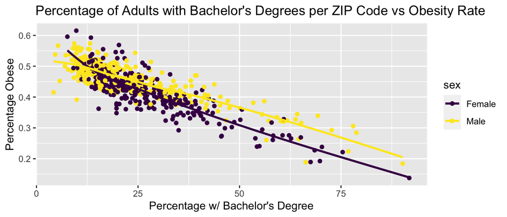

```r
joined %>%
  ggplot(aes(x=pct_bach, y=obese_p, color=sex)) +
  geom_point() +
  geom_smooth(se=FALSE) +
  xlab("Percentage w/ Bachelor's Degree") +
  ylab("Percentage Obese") +
  ggtitle("Percentage of Adults with Bachelor's Degrees per ZIP Code vs Obesity Rate")
```

Comment on patterns in the plot of the data. What is the evident relationship between obesity and obtaining a college education?

There seems to be a negative linear relationship between obtaining a college education and obesity. Zip codes with higher percentages of adults who have completed college tend to have lower obesity rates than those with a low percentage of college graduates. It also would appear that male obesity rates are higher than those of females throughout most zip codes in the state.